# A study on how factors impact business rating stars based on Yelp dataset

Student: Yifan Zhu - ID1006345849

## INTRODUCTION

### - Background

As more people use social media and applications on smart phone, the proliferation of consumer review platforms such as Yelp.com, where people can share their comments and rate their experience has become popular. It is convenient to use Yelp.com since it covers almost all categories in everyday life. This paper analyses review stars of business provided by Yelp dataset, and focus on the correlation between review stars and various independent variables.

### - Source of Data

To investigate the correlation, the writer download the data set of 'yelp_academic_dataset_business.json' from Kaggle website, a famous data science community. Source link: https://www.kaggle.com/yelp-dataset/yelp-dataset?select=yelp_academic_dataset_business.json. This dataset contains with 209393 listed business on Yelp with 14 columns, providing the information such as city, states, stars, review counts, business hours. In order to make it more straight forward, the writer cleans the missing data and only keep variables that are needed for this analysis.

### - Explaination of Studied Variables

From our personal experience using Yelp.com, we prefer places with more reviews and higher stars since it is more reliable. In the following report, the writer will show whether rating stars are correlated with business location and number of reviews using programming and visualization.

## PROJECT ONE

```python
# PART ONE
# set up
import pandas as pd
import seaborn as sns
import numpy as np
import matplotlib.pyplot as plt
import geopandas as gpd
import matplotlib.pyplot as plt
import pandas as pd

from shapely.geometry import Point

%matplotlib inline
# activate plot theme
import qeds
qeds.themes.mpl_style();

# import dataset
import json
import os
print(os.listdir("/Users/yvonne_zhu/Desktop/ECO225/ECO225 Project-1"))

users = []
with open('/Users/yvonne_zhu/Desktop/ECO225/ECO225 Project-1/yelp_academic_dataset_business.json') as fl:
    for i, line in enumerate(fl):
        users.append(json.loads(line))
        if i+1 >= 209393:
            break
df = pd.DataFrame(users)
df.info()
```

```
['.DS_Store', 'Project One Guidelines.pdf', 'Zhu_YIfan_project1.pdf', 'Yifan_Zhu_project1.html', 'yelp_academic_dataset_business.json']
<class 'pandas.core.frame.DataFrame'>
RangeIndex: 209393 entries, 0 to 209392
Data columns (total 14 columns):
 #   Column        Non-Null Count   Dtype
---  ------        --------------   -----
 0   business_id   209393 non-null  object
 1   name          209393 non-null  object
 2   address       209393 non-null  object
 3   city          209393 non-null  object
 4   state         209393 non-null  object
 5   postal_code   209393 non-null  object
 6   latitude      209393 non-null  float64
 7   longitude     209393 non-null  float64
 8   stars         209393 non-null  float64
 9   review_count  209393 non-null  int64
 10  is_open       209393 non-null  int64
 11  attributes    180348 non-null  object
 12  categories    208869 non-null  object
 13  hours         164550 non-null  object
dtypes: float64(3), int64(2), object(9)
memory usage: 22.4+ MB
```

```python
# checking missing values in the data set and printing the percentage for missing volues for each columns
count = df.isnull().sum().sort_values(ascending=False)
percentage = ((df.isnull().sum()/len(df)*100)).sort_values(ascending=False)
missing_data = pd.concat([count, percentage], axis=1,keys = ["count","percentage"])

# drop the missing data
df_clean=df.dropna()
df_clear = df_clean.drop(columns=["address","postal_code","hours","attributes"])
df_clear.head()
# our cleaned data is ready to be used in the following analysis
```

|  | business_id | name | city | state | latitude | longitude | stars | review_count | is_open | categories |
| --- | --- | --- | --- | --- | --- | --- | --- | --- | --- | --- |
| 0 | f9NumwFMBDn751xgFiRbNA | The Range At Lake Norman | Cornelius | NC | 35.462724 | -80.852612 | 3.5 | 36 | 1 | Active Life, Gun/Rifle Ranges, Guns & Ammo, Sh... |
| 3 | 6OAZjbxqM5ol29BuHsil3w | Nevada House of Hose | North Las Vegas | NV | 36.219728 | -115.127725 | 2.5 | 3 | 0 | Hardware Stores, Home Services, Building Suppl... |
| 4 | 51M2Kk903DFYI6gnB5I6SQ | USE MY GUY SERVICES LLC | Mesa | AZ | 33.428065 | -111.726648 | 4.5 | 26 | 1 | Home Services, Plumbing, Electricians, Handyma... |
| 5 | cKyLV5oWZJ2NudWgqs8VZw | Oasis Auto Center - Gilbert | Gilbert | AZ | 33.350399 | -111.827142 | 4.5 | 38 | 1 | Auto Repair, Automotive, Oil Change Stations, ... |
| 6 | oiAlXZPIFm2nBCt0DHLu_Q | Green World Cleaners | Las Vegas | NV | 36.063977 | -115.241463 | 3.5 | 81 | 1 | Dry Cleaning & Laundry, Local Services, Laundr... |

### Statistics Summary

```python
# show summary table of summary stats
df_summary = df_clear.drop(columns=["name","state","latitude","longitude","categories","is_open"])
df_summary.describe().transpose()
```

|  | count | mean | std | min | 25% | 50% | 75% | max |
| --- | --- | --- | --- | --- | --- | --- | --- | --- |
| stars | 146796.0 | 3.664998 | 0.945274 | 1.0 | 3.0 | 4.0 | 4.5 | 5.0 |
| review_count | 146796.0 | 47.920025 | 144.895868 | 3.0 | 6.0 | 13.0 | 39.0 | 10129.0 |

### - Stars with City Location

The first bar chart ('Top 10 Cities by Listed Business on Yelp') shows the top 10 cities by number of listed business on Yelp. Las Vegas, Phoenix and Toronto rank the top 3 cities while Las Vegas is far ahead of other cities, which is not surprising.

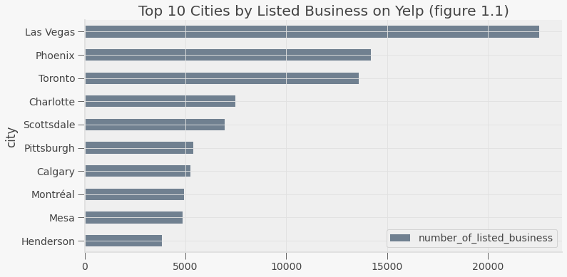

```python
# Top cities by number of business listed
business = df_clear.drop(columns=["name","state","latitude","longitude","review_count","categories","is_open"])
business_counts = business[['city', 'business_id']].groupby(['city'])\
['business_id'].agg('count').sort_values(ascending=False)
business_counts = pd.DataFrame(data=business_counts)

# Sort by the number of business and plot into bar chart
business_counts.rename(columns={'business_id' : 'number_of_listed_business'}, inplace=True)
sub1=business_counts[0:10].sort_values(ascending=True, by="number_of_listed_business")\
.plot(kind='barh', stacked=False, figsize=[12,6], color='slategrey')
plt.title('Top 10 Cities by Listed Business on Yelp (figure 1.1)')
```

The second bar chart ('Top 10 Cities with Stars 5.0') compares the number of getting stars 5.0 among cities. We find that Las Vegas and Phoenix not only have the largest amount of business listed on Yelp but also own the largest amount of stars 5.0 from customer review. This finding is not surprising because those cities attract millions of visitors per year, which boosts local economics, businesses and quality of services; therefore, we can conclude that city where business located plays an important role in getting review stars

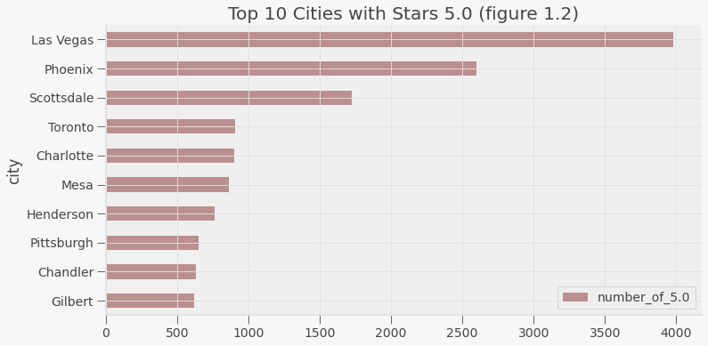

```python
# get the business with stars 5.0
stars5= business.loc[business['stars'] == 5.0]
city5 = stars5.drop(columns=['stars'])
city5.head()

# group 5.0 business by its city
business_counts2 = city5[['city', 'business_id']].groupby(['city'])\
['business_id'].agg('count').sort_values(ascending=False)
business_counts2 = pd.DataFrame(data=business_counts2)
business_counts2.rename(columns={'business_id' : 'number_of_5.0'}, inplace=True)

# select the top 10 cities and plot the bar chart
city_top_10 = business_counts2.head(10)
sub2=city_top_10.sort_values(ascending=True, by='number_of_5.0')\
.plot(kind='barh', stacked=False, figsize=[12,6], color="rosybrown")
plt.title('Top 10 Cities with Stars 5.0 (figure 1.2)')
```

### - Stars with Review Counts

- Total Review Number with Review Stars

It is more likely to get a higher stars if more people is willing to write review of certain business. Among all customer review, most people leave with stars 4.0 followed by 3.5 and 4.5. It is relatively intersting since it is more likely to give high recommendations if customers have a great experience and leave bad comments if they are very unsatisfied. However, our review counts does not lay at these two extremes (see the 'Review Distribution' below).

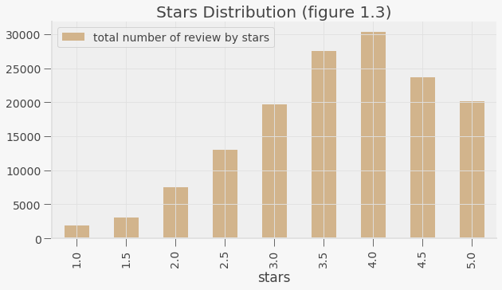

```python
# stars analysis in bar chart and its feature
review_stars_total = df_clear.drop(columns=["business_id","name","city",
                                            "state","latitude","longitude","categories","is_open"])

# group by stars and count the total number for each stars
stars_num_total = review_stars_total.groupby("stars").count()
stars_nums_total = stars_num_total.rename(columns={'review_count': 'total number of review by stars'})
bar_total = stars_nums_total.plot.bar(color="tan", figsize=[10,5])
plt.title("Stars Distribution (figure 1.3)")
```

- Review Count for Single Business

'Review Count for Single Business' shown below, there exists positive correlation between the number of review counts and stars for business below 4.0, but negative correlation when business stars above 4.0. Also, the distribution is similar to the 'Stars Distribution'. As the statistics summary illustrate in the previous part, the overall rating converges to an average of 3.66.

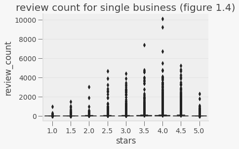

```python
# review count for single business with different stars
sns.boxplot(data=review_stars_total, x='stars', y='review_count')
plt.title('review count for single business (figure 1.4)')
```

### - Compare Closed and Open Business

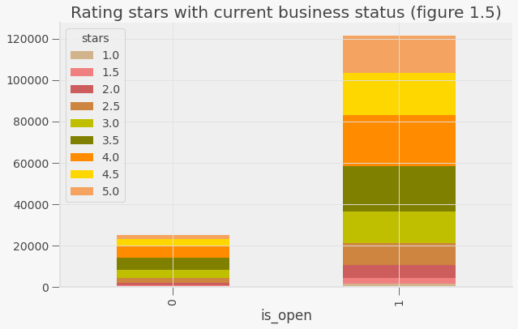

```python
# analysis the stars distribution in open and closed business
oc = df_clear.drop(columns=["name","city","state","latitude","longitude","review_count","categories"])
oc["business_id"] = "1"
oc['business_id'] = pd.to_numeric(oc['business_id'])
oc.groupby(['is_open','stars']).size().unstack().plot(kind='bar',stacked=True, figsize=[10,6],
                                                      color=['tan', 'lightcoral',
                                               "indianred", 'peru', 'y', 'olive',"darkorange","gold","sandybrown"])
plt.title("Rating stars with current business status (figure 1.5)")
plt.show()
```

### - Potential Correlations

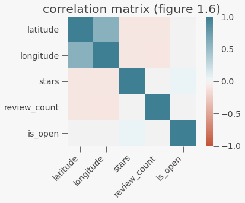

```python
# analysis other correlations
corr = df_clear.corr()
ax = sns.heatmap(
    corr,
    vmin=-1, vmax=1, center=0,
    cmap=sns.diverging_palette(20, 220, n=200),
    square=True
)
ax.set_xticklabels(
    ax.get_xticklabels(),
    rotation=45,
    horizontalalignment='right'
);
plt.title("correlation matrix (figure 1.6)")
```

## Section One

### - THE MESSAGE

Project one tell us about some basic correlations between business rating stars with cities/ locations, number of review and current business status. The Project two focuses on the data of Canada, we will first analysis those coorelations at the provincial level (Ontario), and then select Toronto as our main study topic. The main purpose of this study is to deliver information by staightforward visualizations based on subgroups and adding geographic index such as longitude and latitude.

```python
# center my plot
from IPython.core.display import HTML
HTML("""
<style>
.output_png {
    display: table-cell;
    text-align: center;
    vertical-align: middle;
}
</style>
""")
```

```python
# checking missing values in the data set and printing the percentage for missing volues for each columns
count = df.isnull().sum().sort_values(ascending=False)
percentage = ((df.isnull().sum()/len(df)*100)).sort_values(ascending=False)
missing_data = pd.concat([count, percentage], axis=1,keys = ["count","percentage"])

# drop the missing data and create subset for business only in Canada
df_clean=df.dropna()
df_project = df_clean.drop(columns=["address","postal_code","categories","name","hours","attributes"])
df_ca = df_project.loc[df_project['state'].isin(['NL','PE','NS','NB','QC','ON','MB','SK','AB','BC','YT','NT','NU'])]

# prepare the coordinates (x,y)
import warnings
warnings.filterwarnings("ignore")

df_ca["Coordinates"]=list(zip(df_ca.longitude, df_ca.latitude))
df_ca["Coordinates"]=df_ca["Coordinates"].apply(Point)

gdf_ca = gpd.GeoDataFrame(df_ca, geometry="Coordinates")
gdf_ca.head()
```

|  | business_id | city | state | latitude | longitude | stars | review_count | is_open | Coordinates |
| --- | --- | --- | --- | --- | --- | --- | --- | --- | --- |
| 9 | EosRKXIGeSWFYWwpkbhNnA | Toronto | ON | 43.624539 | -79.529108 | 3.0 | 16 | 1 | POINT (-79.52911 43.62454) |
| 24 | eBEfgOPG7pvFhb2wcG9I7w | Aurora | ON | 44.010962 | -79.448677 | 4.5 | 4 | 1 | POINT (-79.44868 44.01096) |
| 26 | 1wWneWD_E1pBIyVpdHMaQg | Toronto | ON | 43.656542 | -79.381308 | 4.0 | 9 | 1 | POINT (-79.38131 43.65654) |
| 29 | 007Dg4ESDVacWcC4Vq704Q | Toronto | ON | 43.603232 | -79.538424 | 4.0 | 8 | 0 | POINT (-79.53842 43.60323) |
| 30 | 9sRGfSVEfLhN_km60YruTA | Richmond Hill | ON | 43.947011 | -79.454862 | 3.0 | 3 | 1 | POINT (-79.45486 43.94701) |

### - Business in Ontario

- Figure 2.1 below shows business in Ontario. It is obvious that number of business getting 3.5 (5662) is the highest among all groups followed by stars 4.0 (5270) and 3.0 (4077). Those three groups contribute more than half amount of the listed business on Yelp.

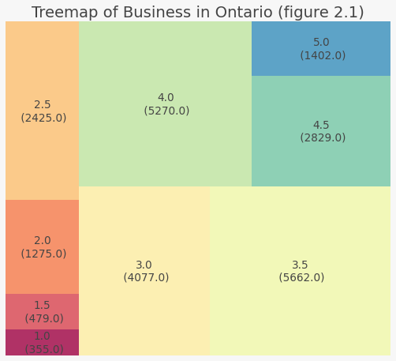

```python
# Treemap of Business in Ontario
# ! pip install squarify
import squarify
df_ON = df_ca[df_ca['state']=="ON"]
df = df_ON.groupby('stars').size().reset_index(name='counts')
labels = df.apply(lambda x: str(x[0]) + "\n (" + str(x[1]) + ")", axis=1)
sizes = df['counts'].values.tolist()
colors = [plt.cm.Spectral(i/float(len(labels))) for i in range(len(labels))]

# Draw Plot
plt.figure(figsize=(9,8), dpi= 70)
squarify.plot(sizes=sizes, label=labels, color=colors, alpha=.8)

# Decorate
plt.title('Treemap of Business in Ontario (figure 2.1)')
plt.axis('off')
plt.show()
```

- Different from the project one, jointplot not only shows the relation between review count and rating stars, it also illustrates the distribution of each variables. From the jointplot (figure 2.2) we can conclude the distribution of rating stars follows a left-shewed normal distribution. Also, except sveral outliers the review number for each business is mainly concentrated below 500.

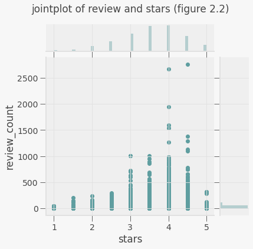

```python
# jointplot stars ~ review
df_j= df_ca.drop(columns=["business_id","city","state","latitude","longitude","is_open","Coordinates"])
df_j.head()
g = sns.jointplot(x='stars',y='review_count',data=df_j,color="cadetblue")
g.fig.suptitle("jointplot of review and stars (figure 2.2)")
g.fig.subplots_adjust(top=0.9)
```

```python
# prepare dataframe for different stars in cities in Ontario
counts = df_ON[['city', 'business_id']].groupby(['city'])\
['business_id'].agg('count').sort_values(ascending=False)
counts = pd.DataFrame(data=counts)
counts.rename(columns={'business_id' : 'number of business'}, inplace=True)

stars5= df_ON[df_ON['stars'] == 5.0]
city_5 = stars5.drop(columns=['stars'])
counts_5 = city_5[['city', 'business_id']].groupby(['city'])\
['business_id'].agg('count').sort_values(ascending=False)
counts_5 = pd.DataFrame(data=counts_5)
counts_5.rename(columns={'business_id' : '5 stars'}, inplace=True)

stars45= df_ON[df_ON['stars'] == 4.5]
city_45 = stars45.drop(columns=['stars'])
counts_45 = city_45[['city', 'business_id']].groupby(['city'])\
['business_id'].agg('count').sort_values(ascending=False)
counts_45 = pd.DataFrame(data=counts_45)
counts_45.rename(columns={'business_id' : '4.5 stars'}, inplace=True)

stars4= df_ON[df_ON['stars'] == 4.0]
city_4 = stars4.drop(columns=['stars'])
counts_4 = city_4[['city', 'business_id']].groupby(['city'])\
['business_id'].agg('count').sort_values(ascending=False)
counts_4 = pd.DataFrame(data=counts_4)
counts_4.rename(columns={'business_id' : '4.0 stars'}, inplace=True)

stars35= df_ON[df_ON['stars'] == 3.5]
city_35 = stars35.drop(columns=['stars'])
counts_35 = city_35[['city', 'business_id']].groupby(['city'])\
['business_id'].agg('count').sort_values(ascending=False)
counts_35 = pd.DataFrame(data=counts_35)
counts_35.rename(columns={'business_id' : '3.5 stars'}, inplace=True)

stars3= df_ON[df_ON['stars'] == 3.0]
city_3 = stars3.drop(columns=['stars'])
counts_3 = city_3[['city', 'business_id']].groupby(['city'])\
['business_id'].agg('count').sort_values(ascending=False)
counts_3 = pd.DataFrame(data=counts_3)
counts_3.rename(columns={'business_id' : '3.0 stars'}, inplace=True)

stars25= df_ON[df_ON['stars'] == 2.5]
city_25 = stars25.drop(columns=['stars'])
counts_25 = city_25[['city', 'business_id']].groupby(['city'])\
['business_id'].agg('count').sort_values(ascending=False)
counts_25 = pd.DataFrame(data=counts_25)
counts_25.rename(columns={'business_id' : '2.5 stars'}, inplace=True)

stars2= df_ON[df_ON['stars'] == 2.0]
city_2= stars2.drop(columns=['stars'])
counts_2 = city_2[['city', 'business_id']].groupby(['city'])\
['business_id'].agg('count').sort_values(ascending=False)
counts_2 = pd.DataFrame(data=counts_2)
counts_2.rename(columns={'business_id' : '2.0 stars'}, inplace=True)

stars15= df_ON[df_ON['stars'] == 1.5]
city_15= stars15.drop(columns=['stars'])
counts_15 = city_15[['city', 'business_id']].groupby(['city'])\
['business_id'].agg('count').sort_values(ascending=False)
counts_15 = pd.DataFrame(data=counts_15)
counts_15.rename(columns={'business_id' : '1.5 stars'}, inplace=True)

stars1= df_ON[df_ON['stars'] == 1.0]
city_1= stars1.drop(columns=['stars'])
counts_1 = city_1[['city', 'business_id']].groupby(['city'])\
['business_id'].agg('count').sort_values(ascending=False)
counts_1 = pd.DataFrame(data=counts_1)
counts_1.rename(columns={'business_id' : '1.0 stars'}, inplace=True)

# merge three dataframe
df_count = pd.concat([counts, counts_5, counts_45, counts_4,counts_35, counts_3,counts_25,counts_2,counts_15,
                     counts_1], axis=1)
df_count= df_count.rename_axis('city')
df_count.head()
```

| city | number of business | 5 stars | 4.5 stars | 4.0 stars | 3.5 stars | 3.0 stars | 2.5 stars | 2.0 stars | 1.5 stars | 1.0 stars |
| --- | --- | --- | --- | --- | --- | --- | --- | --- | --- | --- |
| Toronto | 13600 | 907.0 | 1859.0 | 3259.0 | 3206.0 | 2194.0 | 1173.0 | 630.0 | 221.0 | 151.0 |
| Mississauga | 2226 | 101.0 | 220.0 | 485.0 | 495.0 | 397.0 | 279.0 | 139.0 | 66.0 | 44.0 |
| Markham | 1240 | 64.0 | 103.0 | 226.0 | 340.0 | 271.0 | 144.0 | 55.0 | 24.0 | 13.0 |
| Richmond Hill | 762 | 31.0 | 58.0 | 123.0 | 203.0 | 169.0 | 97.0 | 55.0 | 11.0 | 15.0 |
| Vaughan | 731 | 40.0 | 83.0 | 139.0 | 185.0 | 126.0 | 81.0 | 42.0 | 21.0 | 14.0 |

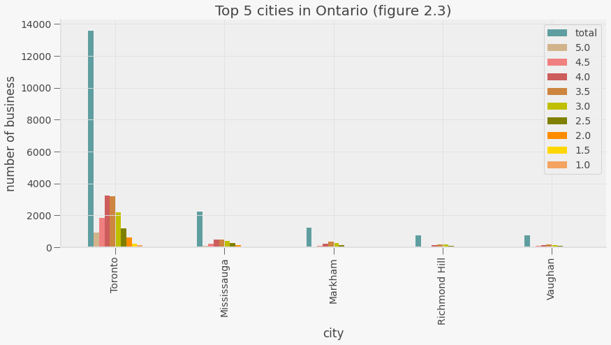

```python
# barplot: Top 5 cities in Ontario
plotdata = pd.DataFrame({
    "total":[13600,2226,1240,762,731],
    "5.0":[907, 101,64,31,40],
    "4.5":[1859,220,103,58,83],
    "4.0":[3259,485,226,123,139],
    "3.5":[3206,495,340,203,185],
    "3.0":[2194,397,271,169,126],
    "2.5":[1173,279,144,97,81],
    "2.0":[630,139,55,55,42],
    "1.5":[221,66,24,11,21],
    "1.0": [151,44,13,15,14]
    },
    index=['Toronto', 'Mississauga', 'Markham','Richmond Hill','Vaughan']
)
plotdata.plot(kind="bar",figsize=(14,6),color=['cadetblue', 'tan', 'lightcoral',
                                               "indianred", 'peru', 'y', 'olive',"darkorange","gold","sandybrown"])
plt.title("Top 5 cities in Ontario (figure 2.3)")
plt.xlabel("city")
plt.ylabel("number of business")
```

[figure not shown]

```python
df_trt = df_ON[df_ON['city']=="Toronto"]
df_miss = df_ON[df_ON['city']=="Mississauga"]
df_mark = df_ON[df_ON['city']=="Markham"]
df_rich = df_ON[df_ON['city']=="Richmond Hill"]

f, axes = plt.subplots(2, 2, figsize=(12, 9), sharex=True)

f1 = sns.distplot(df_trt["stars"] ,color="skyblue", label="Toronto",ax=axes[0,0])
f2 = sns.distplot(df_miss["stars"] , color="orange", label="Mississauga",ax=axes[0, 1])
f3 = sns.distplot(df_mark["stars"] , color="darksalmon", label="Markham", ax=axes[1, 0])
f4 = sns.distplot(df_miss["stars"] , color="olive", label="Richmond Hill",ax=axes[1, 1])
plt.title(label="business across four cities (figure 2.4)",fontsize=20, x=-0.2,y=2.3)

f1.title.set_text('Toronto')
f2.title.set_text('Mississauga')
f3.title.set_text('Markham')

plt.legend()
plt.show()
```

- The economy of Toronto is the largest contributor to the Canadian economy, at 20% of national GDP. Toronto is a commercial, distribution, financial and industrial centre, it is worth analysis the business in Toronto. We create the subset for Toronto and create the circle plot, figure 2.5. Similar to our previous analysis, in business in Toronto is concentrated in stars 4.0 and stars 3.5, but there are fewer businesses below stars 2.0. In other words, the average review of Toronto is quite high.

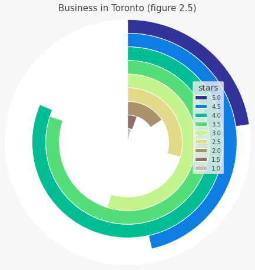

```python
# circle plot for business in Toronto
import matplotlib.pyplot as plt
from matplotlib import cm
from math import log10

labels = ["5.0","4.5","4.0","3.5","3.0","2.5","2.0","1.5","1.0"]
data = [907, 1859, 3259, 3206, 2194, 1173, 630, 221, 151]
n = len(data)
k = 10 ** int(log10(max(data)))
m = k * (1 + max(data) // k)
r = 2.4
w = r / n
colors = [cm.terrain(i / n) for i in range(n)]

fig, ax = plt.subplots()
ax.axis("equal")
for i in range(n):
    innerring, _ = ax.pie([m - data[i], data[i]], radius = r - i * w,
                          startangle = 90, labels = ["", labels[i]],
                          labeldistance = 1 - 1 / (1.5 * (n - i)), textprops = {"alpha": 0},
                          colors = ["white", colors[i]])
    plt.setp(innerring, width = w, edgecolor = "white")

plt.title(label="Business in Toronto (figure 2.5)",fontsize=15, y=1.5)
plt.legend(loc=1, prop={'size': 10},title = 'stars')
plt.show()
```

## Section Two: Mapping

### - Business Location: major roads and buildings

```python
# prepare dataframe for 5 stars business in Ontario
df_0 = city_5[city_5["state"]=="ON"]
lalg_ON = df_0[['city', 'longitude', 'latitude','Coordinates']]
# prepare dataframe for Toronto (all business in Toronto)
df_trt = df_ON[df_ON['city']=="Toronto"]
df_trt.head()
```

|  | business_id | city | state | latitude | longitude | stars | review_count | is_open | Coordinates |
| --- | --- | --- | --- | --- | --- | --- | --- | --- | --- |
| 9 | EosRKXIGeSWFYWwpkbhNnA | Toronto | ON | 43.624539 | -79.529108 | 3.0 | 16 | 1 | POINT (-79.52911 43.62454) |
| 26 | 1wWneWD_E1pBIyVpdHMaQg | Toronto | ON | 43.656542 | -79.381308 | 4.0 | 9 | 1 | POINT (-79.38131 43.65654) |
| 29 | 007Dg4ESDVacWcC4Vq704Q | Toronto | ON | 43.603232 | -79.538424 | 4.0 | 8 | 0 | POINT (-79.53842 43.60323) |
| 73 | 0QjROMVW9ACKjhSEfHqNCQ | Toronto | ON | 43.666376 | -79.348773 | 4.0 | 116 | 1 | POINT (-79.34877 43.66638) |
| 74 | OT-8IUWo_2M-rHddjzz_Cg | Toronto | ON | 43.765266 | -79.166977 | 1.5 | 3 | 1 | POINT (-79.16698 43.76527) |

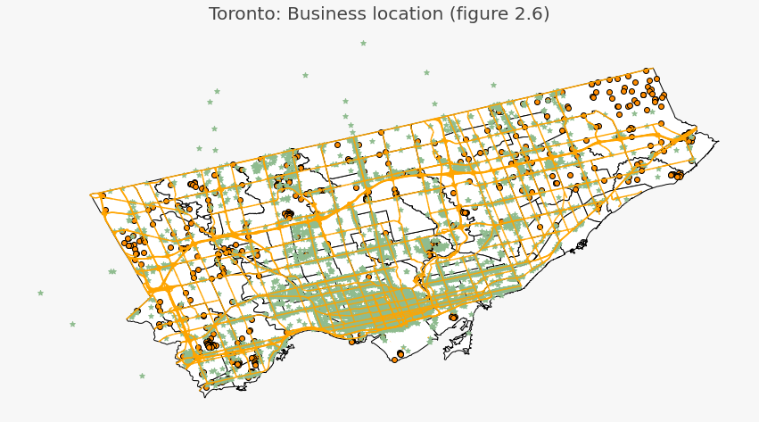

```python
# mapping business in Toronto, major road ~ business ~ building
fig, gax = plt.subplots(figsize=(15,15))

nb = '/Users/yvonne_zhu/Desktop/ECO225 Project-2_Oct_28/Neighbourhoods/Neighbourhoods.shp'
regions = gpd.read_file(nb)
regions['neighbourhood'] = regions['FIELD_7'].str.replace(' \(.+\)', '').str.lower()
regions.plot(ax=gax, edgecolor='black',color='white')

majorroad_shapefile = '/Users/yvonne_zhu/Desktop/ECO225 Project-2_Oct_28/ONhrd/ONhrd.shp'
roadshp = gpd.read_file(majorroad_shapefile)
roadshp.plot(ax=gax, edgecolor='black',color='orange')

building_shapefile = '/Users/yvonne_zhu/Desktop/ECO225 Project-2_Oct_28/ONbpp/ONbpp.shp'
builshp = gpd.read_file(building_shapefile)
builshp.plot(ax=gax, edgecolor='black',color='darkorange')

gdf_trt = gpd.GeoDataFrame(df_trt,geometry="Coordinates")
gdf_trt.plot(ax=gax, color="darkseagreen",marker='*', alpha = 1)

gax.set_xlabel('longitude')
gax.set_ylabel('latitude')
gax.set_title('Toronto: Business location (figure 2.6)')

gax.spines['top'].set_visible(False)
gax.spines['right'].set_visible(False)

plt.axis('off')
plt.show()
```

Figure 2.6 combines Toronto's shapefile, major roads and building points (source 1: 2011 Census - Boundary files, Statistics Canada;source 2: Canadian Open Data and Free Geospatial Data Resources). Yellow denotes the major roads, orange denotes buildings, green marked stars denotes business.

- the business location is always chosen near major roads, which makes customers more convenient
- more business locates in Downtown Toronto, which is a buzzing area filled with skyscrapers, restaurants, nightlife, and an eclectic mix of neighbourhoods.
- most buildings are surrounded by plenty of business. However, in the top right corner of this map (eastern part of Scarborough), buildings are surrounded by fewer businesses.

### - Business Location: where 5-stars business locates in the city

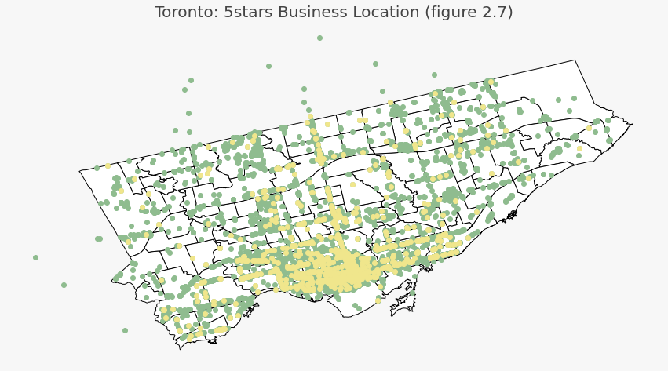

```python
# where the 5 stars business located in Toronto
df_0 = city_5[city_5["state"]=="ON"]
lalg_ON = df_0[['city', 'longitude', 'latitude','Coordinates']]
trt_5 = lalg_ON[lalg_ON["city"]=="Toronto"]

fig, gax = plt.subplots(figsize=(15,15))

regions.plot(ax=gax, edgecolor='black',color='white')

gdf_trt = gpd.GeoDataFrame(df_trt,geometry="Coordinates")
gdf_trt.plot(ax=gax, color="darkseagreen", alpha = 1)

gdf_trt_5 = gpd.GeoDataFrame(trt_5,geometry="Coordinates")
gdf_trt_5.plot(ax=gax, color="khaki", alpha = 1)

gax.set_xlabel('longitude')
gax.set_ylabel('latitude')
gax.set_title('Toronto: 5stars Business Location (figure 2.7)')

gax.spines['top'].set_visible(False)
gax.spines['right'].set_visible(False)

plt.axis('off')
plt.show()
```

Figure 2.7 shows the location where 5 stars business is. The color 'yellow' denotes 5-stars business rating, the 'green' green denotes the business rating from 1.0 to 5.0 (since there is no business rated 0.5 stars in Toronto). As more business locates near the coast, business rated 5 stars located more concentrated in West End, Midtown, Downtown and East End, especially Downtown Toronto.

## - Section Three: Bonus

In this part we will show the business in Toronto similar to figure 2.6 and figure 2.7 above, but using althernative package in Python (Bokeh).

```python
# bokeh setup
from bokeh.io import output_file,show,output_notebook,push_notebook
from bokeh.plotting import *
from bokeh.models import ColumnDataSource,HoverTool,CategoricalColorMapper
from bokeh.layouts import row,column,gridplot,widgetbox
from bokeh.models.widgets import Tabs,Panel
output_notebook()
```

```python
# Bokeh Library
from bokeh.plotting import figure, show, output_file, output_notebook
from bokeh.models import ColumnDataSource, HoverTool, LogColorMapper
import geopandas as gpd
# ! pip install pysal
import pysal as ps

def getLineCoords(row, geom, coord_type):
    """Returns a list of coordinates ('x' or 'y') of a LineString geometry"""
    if coord_type == 'x':
        return list( row[geom].coords.xy[0] )
    elif coord_type == 'y':
        return list( row[geom].coords.xy[1] )

p = figure(title="Toronto Business Location (figure 2.8)")
output_file("Bokeh_output.html")

# plot business
p_df = gdf_trt.drop('Coordinates', axis=1).copy()
psource = ColumnDataSource(p_df)
p.circle('longitude', 'latitude', source=psource, color='tan', size=4)

# TTC shapefile mapping
TTC = '/Users/yvonne_zhu/Desktop/ECO225 Project-2_Oct_28/ONrll_TTC_subway/DMTI2012_Subway.shp'
ttcshp = gpd.read_file(TTC)
ttcshp['x'] = ttcshp.apply(getLineCoords, geom='geometry', coord_type='x', axis=1)
ttcshp['y'] = ttcshp.apply(getLineCoords, geom='geometry', coord_type='y', axis=1)
ttc_df = ttcshp.drop('geometry', axis=1).copy()
msource = ColumnDataSource(ttc_df)
p.multi_line('x', 'y', source=msource, color='sienna', line_width=3)

tooltip = HoverTool()
tooltip.tooltips = [('stars', '@stars'),
                    ('business status', '@is_open'),
                    ('review number', '@review_count')]
p.add_tools(tooltip)

show(p)
```

[interactive chart not shown]

Figure 2.8 shows the business (light brown) and public transport (dark brown), which tells us many business in Toronto cannot be reach by taking TTC (Toronto Transit Commission). This factor indirectly tells us that people in Toronto does not rely on TTC heavily.

# Conclusion

The main goal of this anaylsis is to study the correlation between business rating stars with multiple variables, such as review count, current status (open or closed) and location. The first project focus more on the entire data set, while the second project studies more about business in Ontario (especially city of Toronto) and using mapping skills and means of visualization.